# MACHINE LEARNING MID EXAM

```python
import pandas as pd
data = pd.read_csv('dataset_midexam.csv')
import warnings
warnings.filterwarnings('ignore')

#Extend cell width
from IPython.core.display import display, HTML
display(HTML("<style>.container { width:90% !important; }</style>"))
# Change the width and rerun to see what happens, e.g. 50 and 80
```

```python
data.shape
```

```
(8257, 9)
```

```python
data
```

|  | DEPT | GR | RS | RD | RHOZ | HTNP | HDAR | BATC | DTS |
| --- | --- | --- | --- | --- | --- | --- | --- | --- | --- |
| 0 | 555.0 | 12.3003 | 0.6826 | 0.7422 | -999.25 | -999.25 | -999.25 | -999.25 | -999.25 |
| 1 | 555.5 | 24.5442 | 0.4900 | 0.7223 | -999.25 | -999.25 | -999.25 | -999.25 | -999.25 |
| 2 | 556.0 | 25.4925 | 0.4401 | 0.4498 | -999.25 | -999.25 | -999.25 | -999.25 | -999.25 |
| 3 | 556.5 | 25.2527 | 0.4874 | 0.7347 | -999.25 | -999.25 | -999.25 | -999.25 | -999.25 |
| 4 | 557.0 | 28.6476 | 0.4607 | 0.6694 | -999.25 | -999.25 | -999.25 | -999.25 | -999.25 |
| ... | ... | ... | ... | ... | ... | ... | ... | ... | ... |
| 8252 | 4681.0 | 125.6868 | 5.4640 | 5.7592 | -999.25 | -999.25 | -999.25 | -999.25 | -999.25 |
| 8253 | 4681.5 | 105.7654 | -999.2500 | -999.2500 | -999.25 | -999.25 | -999.25 | -999.25 | -999.25 |
| 8254 | 4682.0 | 119.7699 | -999.2500 | -999.2500 | -999.25 | -999.25 | -999.25 | -999.25 | -999.25 |
| 8255 | 4682.5 | 107.6420 | -999.2500 | -999.2500 | -999.25 | -999.25 | -999.25 | -999.25 | -999.25 |
| 8256 | 4683.0 | 117.8672 | -999.2500 | -999.2500 | -999.25 | -999.25 | -999.25 | -999.25 | -999.25 |

8257 rows × 9 columns

```python
# Making a copyof the data
```

```python
df = data.copy()
```

# Create a regression model to predict Compressional Sonic Log based on other features. Present scores for train and test data set for two best models. You are free to choose the models.

```python
# A value of -999.2500 represents no data. For training and testing delete those form datasets.
```

```python
df['RHOZ'].value_counts()
```

```
-999.2500    6078
 2.5896         7
 2.6119         5
 2.6033         5
 2.5948         5
             ...
 2.5447         1
 2.5432         1
 2.5177         1
 2.4695         1
 2.6280         1
Name: RHOZ, Length: 1532, dtype: int64
```

```python
# At first we will drop columns that have a lot of values of -999.250. Fo example, in columns such as 'Rhoz' "HTNP" "HDAR" and "DTS". The values of -999.250 are around 6000 in each of these columns.
```

```python
df1 = df.drop(['HTNP', 'HDAR', 'DTS', 'RHOZ'], axis=1)
df1
```

|  | DEPT | GR | RS | RD | BATC |
| --- | --- | --- | --- | --- | --- |
| 0 | 555.0 | 12.3003 | 0.6826 | 0.7422 | -999.25 |
| 1 | 555.5 | 24.5442 | 0.4900 | 0.7223 | -999.25 |
| 2 | 556.0 | 25.4925 | 0.4401 | 0.4498 | -999.25 |
| 3 | 556.5 | 25.2527 | 0.4874 | 0.7347 | -999.25 |
| 4 | 557.0 | 28.6476 | 0.4607 | 0.6694 | -999.25 |
| ... | ... | ... | ... | ... | ... |
| 8252 | 4681.0 | 125.6868 | 5.4640 | 5.7592 | -999.25 |
| 8253 | 4681.5 | 105.7654 | -999.2500 | -999.2500 | -999.25 |
| 8254 | 4682.0 | 119.7699 | -999.2500 | -999.2500 | -999.25 |
| 8255 | 4682.5 | 107.6420 | -999.2500 | -999.2500 | -999.25 |
| 8256 | 4683.0 | 117.8672 | -999.2500 | -999.2500 | -999.25 |

8257 rows × 5 columns

```python
df1.shape
```

```
(8257, 5)
```

```python
# Now dropping the rows that contain the specific value of -999.250 from dataset
```

```python
# dropping from RS Column
df2 = df1[df1.RS != -999.250]
df2
```

|  | DEPT | GR | RS | RD | BATC |
| --- | --- | --- | --- | --- | --- |
| 0 | 555.0 | 12.3003 | 0.6826 | 0.7422 | -999.25 |
| 1 | 555.5 | 24.5442 | 0.4900 | 0.7223 | -999.25 |
| 2 | 556.0 | 25.4925 | 0.4401 | 0.4498 | -999.25 |
| 3 | 556.5 | 25.2527 | 0.4874 | 0.7347 | -999.25 |
| 4 | 557.0 | 28.6476 | 0.4607 | 0.6694 | -999.25 |
| ... | ... | ... | ... | ... | ... |
| 8248 | 4679.0 | 76.8100 | 17.3089 | 11.6075 | -999.25 |
| 8249 | 4679.5 | 133.0542 | 3.7683 | 4.4163 | -999.25 |
| 8250 | 4680.0 | 111.5411 | 4.4323 | 5.2930 | -999.25 |
| 8251 | 4680.5 | 122.5865 | 4.0166 | 4.0000 | -999.25 |
| 8252 | 4681.0 | 125.6868 | 5.4640 | 5.7592 | -999.25 |

8247 rows × 5 columns

```python
# Dropping from RD Column
df2 = df1[df1.RD != -999.250]
df2
```

|  | DEPT | GR | RS | RD | BATC |
| --- | --- | --- | --- | --- | --- |
| 0 | 555.0 | 12.3003 | 0.6826 | 0.7422 | -999.25 |
| 1 | 555.5 | 24.5442 | 0.4900 | 0.7223 | -999.25 |
| 2 | 556.0 | 25.4925 | 0.4401 | 0.4498 | -999.25 |
| 3 | 556.5 | 25.2527 | 0.4874 | 0.7347 | -999.25 |
| 4 | 557.0 | 28.6476 | 0.4607 | 0.6694 | -999.25 |
| ... | ... | ... | ... | ... | ... |
| 8248 | 4679.0 | 76.8100 | 17.3089 | 11.6075 | -999.25 |
| 8249 | 4679.5 | 133.0542 | 3.7683 | 4.4163 | -999.25 |
| 8250 | 4680.0 | 111.5411 | 4.4323 | 5.2930 | -999.25 |
| 8251 | 4680.5 | 122.5865 | 4.0166 | 4.0000 | -999.25 |
| 8252 | 4681.0 | 125.6868 | 5.4640 | 5.7592 | -999.25 |

7578 rows × 5 columns

```python
# dropping -999.250 from BATC rows
df2 = df1[df1.BATC != -999.250]
df2
```

|  | DEPT | GR | RS | RD | BATC |
| --- | --- | --- | --- | --- | --- |
| 172 | 641.0 | 42.7609 | 0.9844 | 1.0369 | 161.2563 |
| 173 | 641.5 | 36.0699 | 0.9158 | 1.0299 | 164.7466 |
| 174 | 642.0 | 45.4244 | 0.9119 | 1.0260 | 165.1303 |
| 175 | 642.5 | 48.0399 | 0.8818 | 1.0092 | 160.5973 |
| 176 | 643.0 | 43.4106 | 0.8447 | 0.9860 | 154.9064 |
| ... | ... | ... | ... | ... | ... |
| 8194 | 4652.0 | 154.7616 | 4.9572 | 5.9907 | 81.6122 |
| 8195 | 4652.5 | 162.9701 | 4.7791 | 5.8357 | 81.8643 |
| 8196 | 4653.0 | 161.0100 | 4.5701 | 5.5537 | 82.5599 |
| 8197 | 4653.5 | 153.4006 | 4.8268 | 5.8444 | 82.3704 |
| 8198 | 4654.0 | 136.5053 | 5.5229 | 6.7073 | 80.3989 |

7676 rows × 5 columns

# K- NEIGHBOURS REGRESSOR

```python
import pandas as pd
import numpy as np
import matplotlib.pyplot as plt
import warnings
warnings.filterwarnings("ignore")
```

[output not shown]

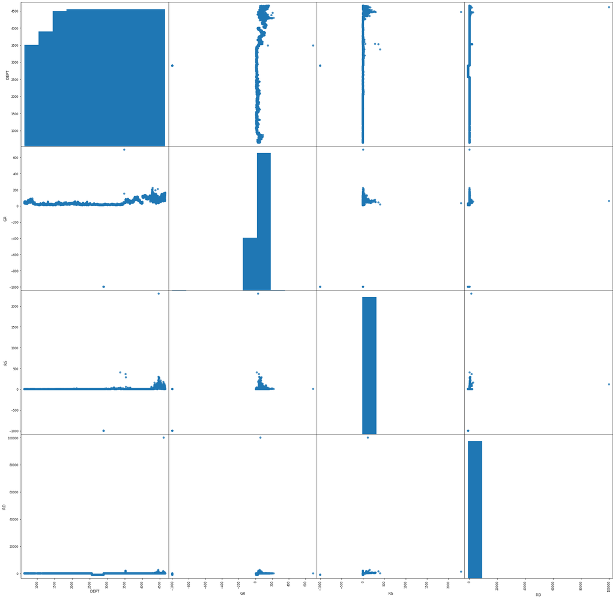

```python
%matplotlib inline
from pandas.plotting import scatter_matrix
features = ['DEPT', 'GR', 'RS', 'RD']
X = df2.loc[:, features]
y = df2.loc[:, ['BATC']]

attributes = df2.drop(columns='BATC')
scatter_matrix(attributes, figsize=(30,30), alpha=0.8, marker='O')
```

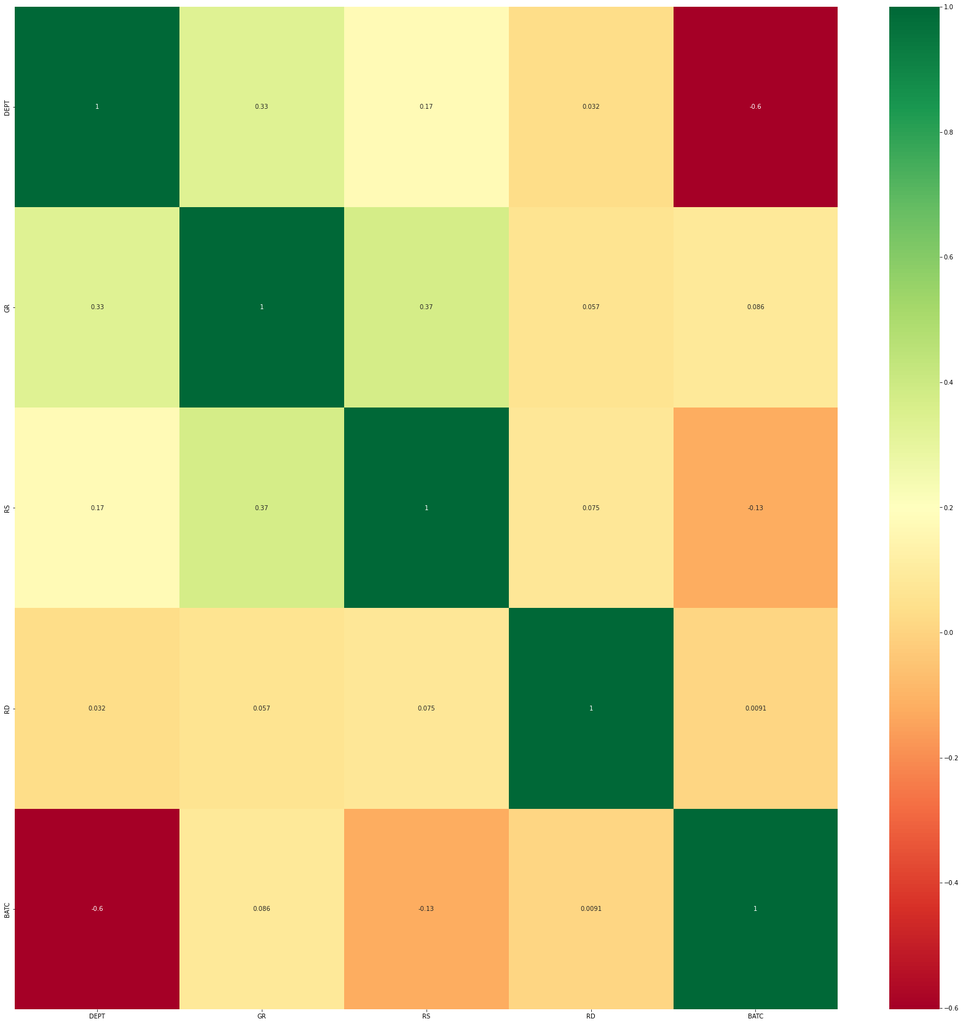

```python
import seaborn as sns
import matplotlib.pyplot as plt

# -- heat map to see corrolation between features
corrmat = df2.corr()
top_corr_features = corrmat.index
plt.figure(figsize=(30,30))

# -- plot heat map
sns.heatmap(df2[top_corr_features].corr(),annot=True,cmap="RdYlGn",)
```

```python
X.head()
```

|  | DEPT | GR | RS | RD |
| --- | --- | --- | --- | --- |
| 172 | 641.0 | 42.7609 | 0.9844 | 1.0369 |
| 173 | 641.5 | 36.0699 | 0.9158 | 1.0299 |
| 174 | 642.0 | 45.4244 | 0.9119 | 1.0260 |
| 175 | 642.5 | 48.0399 | 0.8818 | 1.0092 |
| 176 | 643.0 | 43.4106 | 0.8447 | 0.9860 |

```python
from sklearn.neighbors import KNeighborsRegressor
from sklearn.preprocessing import MinMaxScaler
from sklearn.model_selection import train_test_split

X_train_org, X_test_org, y_train, y_test = train_test_split(X,y, random_state = 0)

scaler = MinMaxScaler()
X_train = scaler.fit_transform(X_train_org)
X_test = scaler.transform(X_test_org)
```

```python
X_train_org, X_test_org, y_train, y_test = train_test_split(X, y, random_state = 0, test_size = 0.25)

scaler = MinMaxScaler()
X_train = scaler.fit_transform(X_train_org)
X_test = scaler.transform(X_test_org)
```

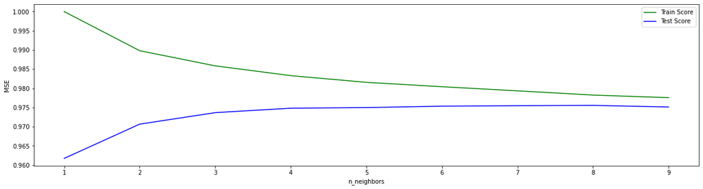

```python
%matplotlib inline
train_score_array = []
test_score_array = []

for k in range(1,10):
    knn_reg = KNeighborsRegressor(k)
    knn_reg.fit(X_train, y_train)
    train_score_array.append(knn_reg.score(X_train, y_train))
    test_score_array.append(knn_reg.score(X_test, y_test))

x_axis = range(1,10)
plt.subplots(figsize = (20,5))
plt.plot(x_axis, train_score_array, c = 'g', label = 'Train Score')
plt.plot(x_axis, test_score_array, c = 'b', label = 'Test Score')
plt.legend()
plt.xlabel('n_neighbors')
plt.ylabel('MSE')
```

```python
np.where(X.columns == 'DEPT')
```

```
(array([0]),)
```

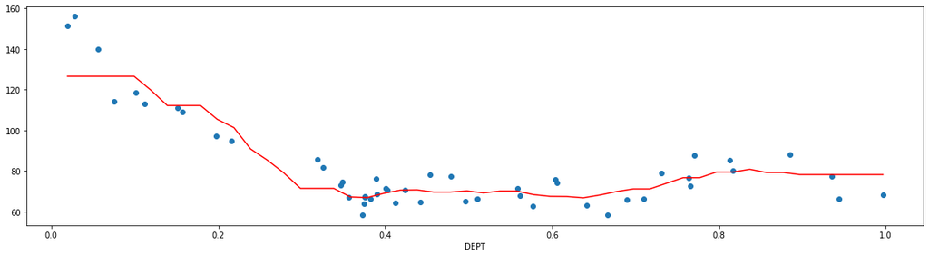

```python
X_b = X_train[:50,0].reshape(-1,1)
y_b = y_train[:50]

knn_reg = KNeighborsRegressor(8)
knn_reg.fit(X_b, y_b)

X_new=np.linspace(X_b.min(), X_b.max(), 50).reshape(50, 1)
y_predict = knn_reg.predict(X_new)

plt.subplots(figsize = (20,5))
plt.plot(X_new, y_predict, c = 'r')
plt.scatter(X_b, y_b)
plt.xlabel('DEPT')
```

```python
from sklearn.metrics import mean_squared_error

# -- fit algoritem to train data
knn_reg = KNeighborsRegressor(3)
knn_reg.fit(X_train, y_train)

# -- predict target value for test dataset
y_predict_knn = knn_reg.predict(X_test)

# -- comapre target value of the model and abservation for both train and test dataset
print (knn_reg.score(X_train,y_train))
print (knn_reg.score(X_test,y_test))
```

```
0.985847768791905
0.9736570750140313
```

Above we can see the score of KNN Regressor. The score is very good.

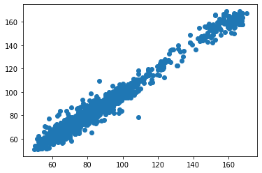

```python
# -- plot measured target value and modeled target values. This model results has no linear distribution for test data set. compare it with the linear regrassion graph.
plt.scatter(y_test, y_predict_knn)
```

# POLYNOMIAL REGRESSION

```python
np.random.seed(0)
X = 6 * np.random.rand(100, 1) - 3
y = 0.5 * X**2 + X + 2 + np.random.randn(100, 1)
```

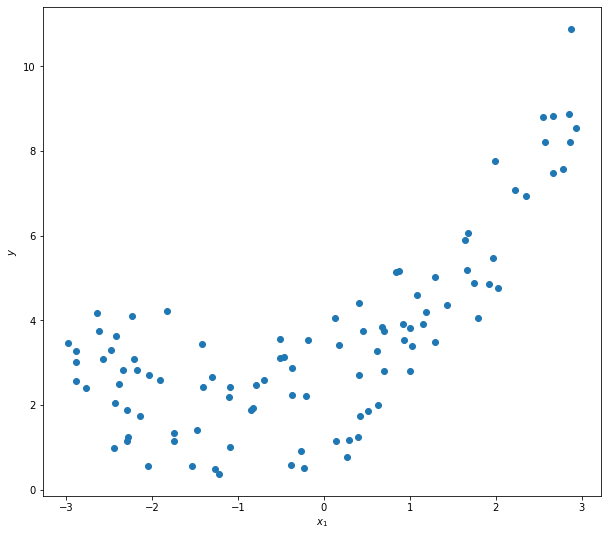

```python
%matplotlib inline

plt.subplots(figsize = (10,9))
plt.scatter(X, y)
plt.xlabel('$x_1$')
plt.ylabel('$y$')
```

```python
from sklearn.linear_model import LinearRegression
from sklearn.preprocessing import PolynomialFeatures

lreg = LinearRegression()
lreg.fit(X,y)

poly = PolynomialFeatures(degree = 2)
X_poly = poly.fit_transform(X)
poly_reg = LinearRegression()
poly_reg.fit(X_poly, y)
```

```
LinearRegression()
```

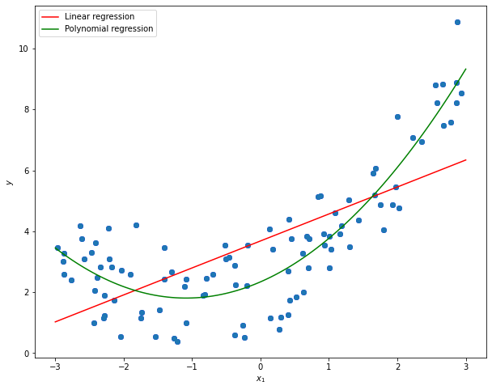

```python
%matplotlib inline

x_axis = np.linspace(-3,3, 100).reshape(-1,1)
plt.subplots(figsize = (10,8))
plt.scatter(X, y, c = 'b')
plt.plot(x_axis, lreg.predict(x_axis), c = 'r', label = 'Linear regression')
plt.plot(x_axis , poly_reg.predict(poly.transform(x_axis)), c = 'g', label = 'Polynomial regression')
plt.scatter(X, y)
plt.legend()
plt.xlabel('$x_1$')
plt.ylabel('$y$')
```

```python
from sklearn.preprocessing import MinMaxScaler
from sklearn.model_selection import train_test_split
import pandas as pd
```

```python
X_train_org, X_test_org, y_train, y_test = train_test_split(X,y, random_state = 0)

scaler = MinMaxScaler()

X_train = scaler.fit_transform(X_train_org)
X_test = scaler.transform(X_test_org)
```

```python
from  sklearn.preprocessing  import PolynomialFeatures

poly = PolynomialFeatures(degree = 2)
X_train_poly = poly.fit_transform(X_train)
X_test_poly = poly.transform(X_test)

poly_reg = LinearRegression()
poly_reg.fit(X_train_poly, y_train)

print(poly_reg.score(X_train_poly, y_train))
print(poly_reg.score(X_test_poly, y_test))
```

```
0.8120285581136351
0.7350062730617648
```

# WE CAN SEE THAT ABOVE SCORE IS GOOD

```python
np.random.seed(0)
X = np.array([i*np.pi/180 for i in range(60,300,4)])
y = np.sin(X) + np.random.normal(0,0.15,len(X))
```

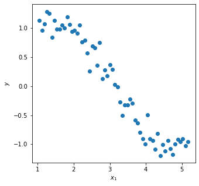

```python
%matplotlib inline

plt.subplots(figsize = (5,5))
plt.scatter(X, y)
plt.xlabel('$x_1$')
plt.ylabel('$y$')
```

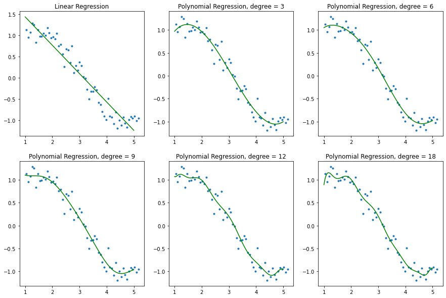

```python
%matplotlib inline

x_values = np.linspace(1,5, 100).reshape(-1,1)

fig, axs = plt.subplots(2, 3, figsize = (15,10))
lreg = LinearRegression()
lreg.fit(X.reshape(-1,1),y)
plt.subplot(2, 3, 1)
plt.scatter(X,y, marker = '.')
plt.plot(x_values, lreg.predict(x_values), c = 'g')
plt.title('Linear Regression')

count = 2
for i in [3, 6, 9, 12, 18]:
    poly = PolynomialFeatures(degree = i)
    X_poly = poly.fit_transform(X.reshape(-1,1))
    lreg.fit(X_poly, y)

    plt.subplot(2, 3, count)
    plt.scatter(X,y, marker = '.')
    plt.plot(x_values, lreg.predict(poly.transform(x_values)), c = 'g')
    plt.title('Polynomial Regression, degree = '+str(i))
    count += 1

plt.savefig('polyreg.jpeg')
```

# Q2: Train a model that classifies formations. Present scores for train and test data set for two best models. You are free to choose the models.

```python
df3 = df2.copy()
```

```python
df3
```

|  | DEPT | GR | RS | RD | BATC |
| --- | --- | --- | --- | --- | --- |
| 172 | 641.0 | 42.7609 | 0.9844 | 1.0369 | 161.2563 |
| 173 | 641.5 | 36.0699 | 0.9158 | 1.0299 | 164.7466 |
| 174 | 642.0 | 45.4244 | 0.9119 | 1.0260 | 165.1303 |
| 175 | 642.5 | 48.0399 | 0.8818 | 1.0092 | 160.5973 |
| 176 | 643.0 | 43.4106 | 0.8447 | 0.9860 | 154.9064 |
| ... | ... | ... | ... | ... | ... |
| 8194 | 4652.0 | 154.7616 | 4.9572 | 5.9907 | 81.6122 |
| 8195 | 4652.5 | 162.9701 | 4.7791 | 5.8357 | 81.8643 |
| 8196 | 4653.0 | 161.0100 | 4.5701 | 5.5537 | 82.5599 |
| 8197 | 4653.5 | 153.4006 | 4.8268 | 5.8444 | 82.3704 |
| 8198 | 4654.0 | 136.5053 | 5.5229 | 6.7073 | 80.3989 |

7676 rows × 5 columns

GIVING FORMATION THEIR NAMES WITH RESPECT TO DEPTH

```python
df3['formation_name']=np.nan
df3['formation_name'].loc[data['DEPT'] < 955.8] = 'Barracouta'
df3['formation_name'].loc[(df3['DEPT'] >= 955.8) & (df3['DEPT'] < 2432.8)] = 'Oliver'
df3['formation_name'].loc[(df3['DEPT'] >= 2432.8) & (df3['DEPT'] < 3459.4)] = 'Prion'
df3['formation_name'].loc[(df3['DEPT'] >= 3459.4) & (df3['DEPT'] < 3778.8)] = 'Johnson'
df3['formation_name'].loc[(df3['DEPT'] >= 3778.8) & (df3['DEPT'] < 4005.2)] = 'Wangarlu'
df3['formation_name'].loc[(df3['DEPT'] >= 4005.2) & (df3['DEPT'] < 4253)] = 'Jamieson'
df3['formation_name'].loc[(df3['DEPT'] >= 4253) & (df3['DEPT'] < 4444)] = 'Plover'
df3['formation_name'].loc[(df3['DEPT'] >= 4444) & (df3['DEPT'] < 4685)] = 'Carnian'
df3.head(8000)
```

|  | DEPT | GR | RS | RD | BATC | formation_name |
| --- | --- | --- | --- | --- | --- | --- |
| 172 | 641.0 | 42.7609 | 0.9844 | 1.0369 | 161.2563 | Barracouta |
| 173 | 641.5 | 36.0699 | 0.9158 | 1.0299 | 164.7466 | Barracouta |
| 174 | 642.0 | 45.4244 | 0.9119 | 1.0260 | 165.1303 | Barracouta |
| 175 | 642.5 | 48.0399 | 0.8818 | 1.0092 | 160.5973 | Barracouta |
| 176 | 643.0 | 43.4106 | 0.8447 | 0.9860 | 154.9064 | Barracouta |
| ... | ... | ... | ... | ... | ... | ... |
| 8194 | 4652.0 | 154.7616 | 4.9572 | 5.9907 | 81.6122 | Carnian |
| 8195 | 4652.5 | 162.9701 | 4.7791 | 5.8357 | 81.8643 | Carnian |
| 8196 | 4653.0 | 161.0100 | 4.5701 | 5.5537 | 82.5599 | Carnian |
| 8197 | 4653.5 | 153.4006 | 4.8268 | 5.8444 | 82.3704 | Carnian |
| 8198 | 4654.0 | 136.5053 | 5.5229 | 6.7073 | 80.3989 | Carnian |

7676 rows × 6 columns

```python
df3['formation_name'].unique()
```

```
array(['Barracouta', 'Oliver', 'Prion', 'Johnson', 'Wangarlu', 'Jamieson',
       'Plover', 'Carnian'], dtype=object)
```

NOW APPLYING LABEL ENCODER TO THE FORMATION_NAME COLUMN

```python
#Making a copy of this data
```

```python
df4 = df3.copy()
```

```python
# Import label encoder
from sklearn import preprocessing

# label_encoder object knows how to understand word labels
label_encoder = preprocessing.LabelEncoder()

df4['formation_name']= label_encoder.fit_transform(df4['formation_name'])

df4['formation_name'].unique()
```

```
array([0, 4, 6, 3, 7, 2, 5, 1])
```

```python
df4.head(3000)
```

|  | DEPT | GR | RS | RD | BATC | formation_name |
| --- | --- | --- | --- | --- | --- | --- |
| 172 | 641.0 | 42.7609 | 0.9844 | 1.0369 | 161.2563 | 0 |
| 173 | 641.5 | 36.0699 | 0.9158 | 1.0299 | 164.7466 | 0 |
| 174 | 642.0 | 45.4244 | 0.9119 | 1.0260 | 165.1303 | 0 |
| 175 | 642.5 | 48.0399 | 0.8818 | 1.0092 | 160.5973 | 0 |
| 176 | 643.0 | 43.4106 | 0.8447 | 0.9860 | 154.9064 | 0 |
| ... | ... | ... | ... | ... | ... | ... |
| 3518 | 2314.0 | 28.5858 | 2.4437 | 2.9052 | 68.9640 | 4 |
| 3519 | 2314.5 | 31.5102 | 1.8467 | 2.1437 | 69.2492 | 4 |
| 3520 | 2315.0 | 33.7543 | 2.0566 | 2.4759 | 69.2492 | 4 |
| 3521 | 2315.5 | 28.2403 | 2.2811 | 2.2967 | 68.3076 | 4 |
| 3522 | 2316.0 | 24.1075 | 1.8380 | 2.2511 | 68.3076 | 4 |

3000 rows × 6 columns

```python
# Setting formation_name as a target column for classification purpose.
```

[output not shown]

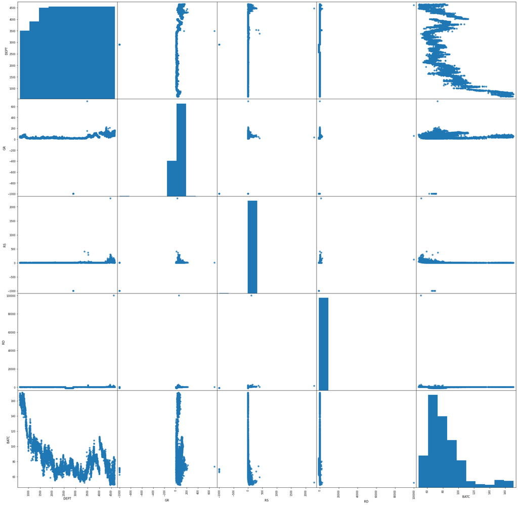

```python
%matplotlib inline
from pandas.plotting import scatter_matrix
features = ['DEPT', 'GR', 'RS', 'RD', 'BATC']
X = df4.loc[:, features]
y = df4.loc[:, ['formation_name']]

attributes = df4.drop(columns='formation_name')
scatter_matrix(attributes, figsize=(30,30), alpha=0.8, marker='O')
```

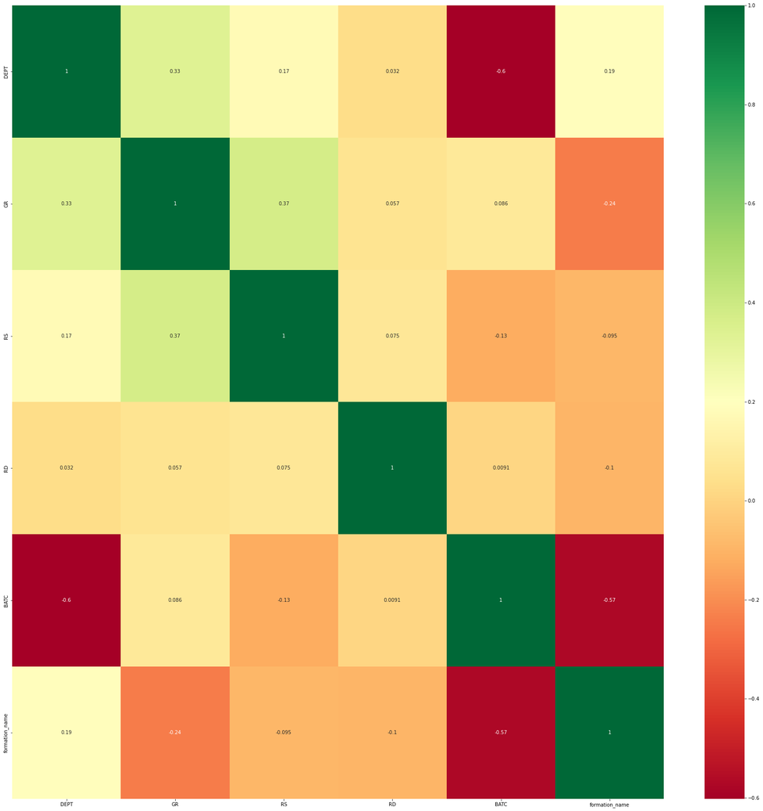

```python
import seaborn as sns
import matplotlib.pyplot as plt

# -- heat map to see corrolation between features
corrmat = df4.corr()
top_corr_features = corrmat.index
plt.figure(figsize=(30,30))

# -- plot heat map
sns.heatmap(df4[top_corr_features].corr(),annot=True,cmap="RdYlGn",)
```

# APPLYING DECISION TREE CLASSIFIER

```python
from sklearn.tree import DecisionTreeClassifier

tree = DecisionTreeClassifier(criterion= 'entropy')
tree.fit(X,y)
```

```
DecisionTreeClassifier(criterion='entropy')
```

```python
pip install graphviz
```

```python
from sklearn.tree import DecisionTreeClassifier

tree = DecisionTreeClassifier(criterion= 'entropy')
tree.fit(X,y)
```

```
DecisionTreeClassifier(criterion='entropy')
```

```python
import os
import graphviz

os.environ["PATH"] += os.pathsep + 'C:/Program Files (x86)/Graphviz2.38/bin/'

# Create DOT data
from sklearn.tree import export_graphviz

dot_data = export_graphviz(tree, out_file=None, filled=True, rounded=True, feature_names=X.columns)

# Draw graph
graph = graphviz.Source(dot_data)

# Show graph
graph
```

[figure not shown]

```python
%matplotlib notebook
from sklearn.tree import DecisionTreeClassifier
from sklearn.model_selection import train_test_split
```

```python
X_train, X_test, y_train, y_test = train_test_split(X, y, random_state=0)

dtree = DecisionTreeClassifier(random_state=0)

dtree.fit(X_train, y_train)
print("Accuracy on training set: {:.3f}".format(dtree.score(X_train, y_train)))
print("Accuracy on test set: {:.3f}".format(dtree.score(X_test, y_test)))
```

```
Accuracy on training set: 1.000
Accuracy on test set: 0.999
```

ABOVE WE CAN SEE THAT FOR DECISION TREE CLASSIFIER, THE SCORE FOR MY DATA IS VERY GOOD.

```python
dtree = DecisionTreeClassifier(max_depth=4, random_state=0)
dtree.fit(X_train, y_train)

print("Accuracy on training set: {:.3f}".format(dtree.score(X_train, y_train)))
print("Accuracy on test set: {:.3f}".format(dtree.score(X_test, y_test)))
```

```
Accuracy on training set: 0.895
Accuracy on test set: 0.897
```

```python
import matplotlib.pyplot as plt
import numpy as np
```

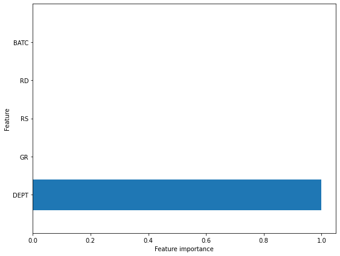

```python
%matplotlib inline

def plot_feature_importances_borehole(model):
    fig, ax = plt.subplots(figsize=(9, 7))
    n_features = X.shape[1]
    plt.barh(range(n_features), model.feature_importances_, align='center')
    plt.yticks(np.arange(n_features), features)
    plt.xlabel("Feature importance")
    plt.ylabel("Feature")
    plt.ylim(-1, n_features)

plot_feature_importances_borehole(dtree)
```

```python
import os
import graphviz

os.environ["PATH"] += os.pathsep + 'C:/Program Files (x86)/Graphviz2.38/bin/'

# Create DOT data
from sklearn.tree import export_graphviz

dot_data = export_graphviz(dtree, out_file=None, filled=True, rounded=True, feature_names=features)

# Draw graph
graph = graphviz.Source(dot_data)

# Show graph
graph
```

[figure not shown]